# HW19

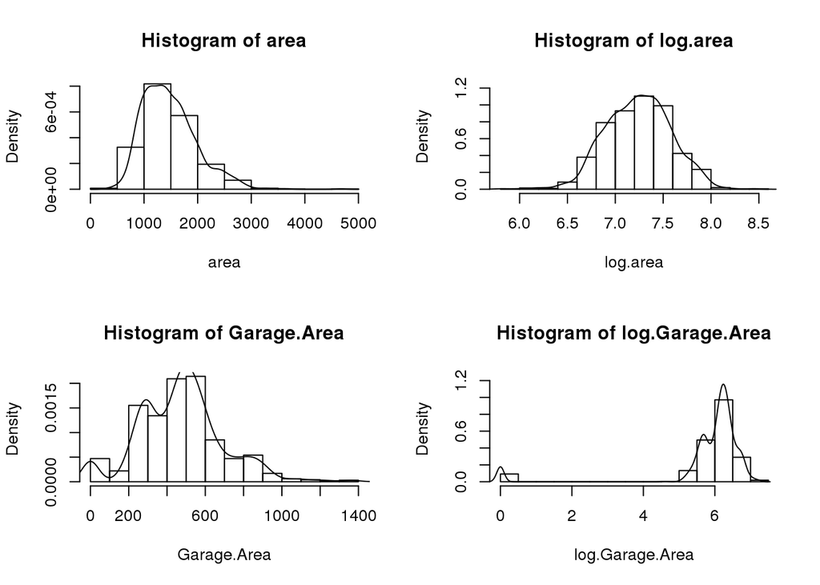

```r
hist(area,freq = FALSE)
lines(density(area))
hist(log.area, freq = FALSE, ylim = c(0,1.25))
lines(density(log.area))
hist(Garage.Area,freq = FALSE)
lines(density(Garage.Area, na.rm = TRUE))
hist(log.Garage.Area, freq = FALSE, ylim = c(0,1.25))
lines(density(log.Garage.Area, na.rm = TRUE))
```

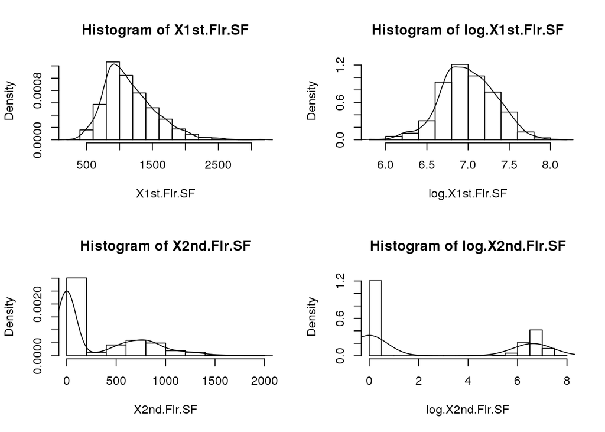

```r
hist(X1st.Flr.SF,freq = FALSE)
lines(density(X1st.Flr.SF, na.rm = TRUE))
hist(log.X1st.Flr.SF, freq = FALSE, ylim = c(0,1.25))
lines(density(log.X1st.Flr.SF, na.rm = TRUE))
hist(X2nd.Flr.SF,freq = FALSE)
lines(density(X2nd.Flr.SF, na.rm = TRUE))
hist(log.X2nd.Flr.SF, freq = FALSE, ylim = c(0,1.25))
lines(density(log.X2nd.Flr.SF, na.rm = TRUE))
```

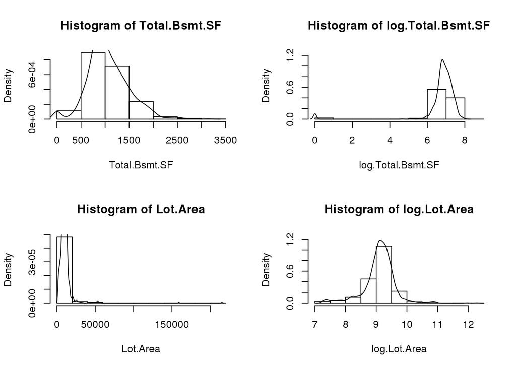

```r
hist(Total.Bsmt.SF,freq = FALSE)
lines(density(Total.Bsmt.SF, na.rm = TRUE))
hist(log.Total.Bsmt.SF, freq = FALSE, ylim = c(0,1.25))
lines(density(log.Total.Bsmt.SF, na.rm = TRUE))
hist(Lot.Area,freq = FALSE)
lines(density(Lot.Area, na.rm = TRUE))
hist(log.Lot.Area, freq = FALSE, ylim = c(0,1.25))
lines(density(log.Lot.Area, na.rm = TRUE))
```

After filtering the data to just get the normal sale types, I would actually probably use the same transformations. I might perform some more box cox transformations

# Question 2

I propose two gamma distributions because those ensure a positive support. I also center those priors on the MLE s for both $v$ and $k$. So $k \sim gamma(.608,4)$ and $v \sim gamma(66.652,4)$. This prior ensures that both of these values are positive, and they will be centered around these values.

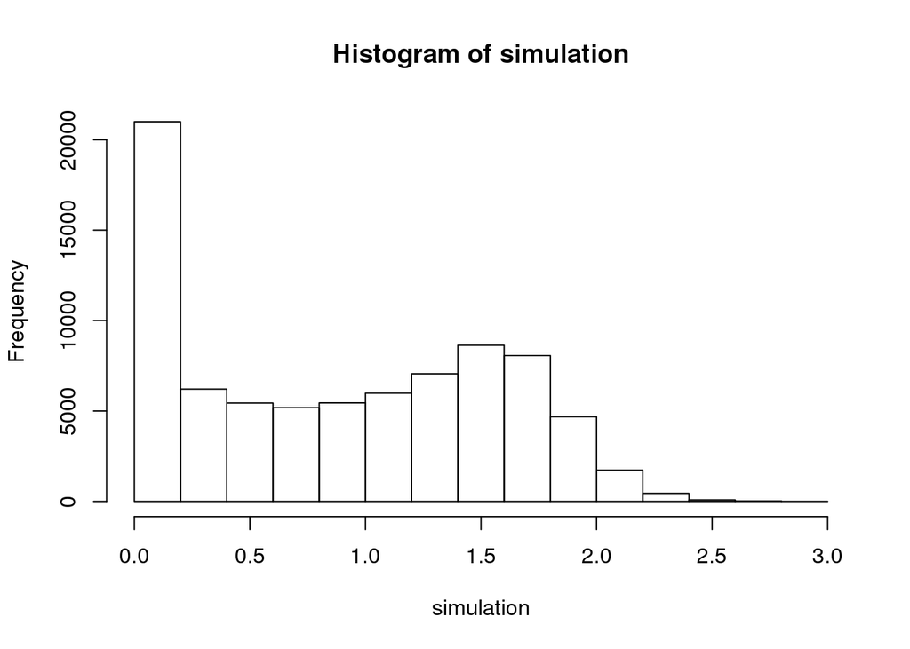

```r
x = c(2,4,6,8,10,24,28, 32)
y = c(1.63, 1.01, .73, .55, .41, .01, .06, .02)

conc.lm = lm(I(log(y) - log(30)) ~ x)

vhat = exp(-coef(conc.lm)[1])
khat = -coef(conc.lm)[2]

v.sims = rgamma(10000,66.652,4)
k.sims = rgamma(10000,.608,4)

mu.func = function(x,V,k){
  return((30/V)*exp(-k*x))
}
simulation = NULL

for(i in 1:length(x)){
  simulation = c(simulation, mu.func(x[i],v.sims,k.sims))
}
hist(simulation)
```

These seem like reasonable values for the data. This makes me think that we can proceed with the model.

## Part B

```r
n = length(x)
data = list(y = y, x=x)
data$n = n
data$D = 30

gamma.model = function(){

    v ~ dgamma(66.652,4)
    k ~ dgamma(.608,4)
  for(i in 1:n) {
    mu[i] <- 30/v * exp(- k * x[i])
    y[i] ~ dnorm(mu[i], phi)
    }
    phi <- sigma^(-2)
    sigma ~ dgamma(1e-6,1e-6)
    halflife <- log(2) / k
    vk <- v * k
}

parms = c("v","k", "phi","sigma", "vk", "halflife")

data = list(y=y, x=x,  n=length(y), D=30)


out.gamma = jags(model = gamma.model, data=data, param=parms, n.iter=50000, n.burnin=5000)
```

```
## module glm loaded
```

```r
#model= function() {
#
#    v ~ dt(0, phi, 1)%_% T(0,)
#    k ~ dt(0,phi, 1)%_% T(0,)
#    b ~ dwish(I, 1)
#    R ~ dwish(I, 1)
#    lambda ~ dgamma(1/2, 1/2)
#    for (i in 1:n) {
#      mu[i] <- D/v * exp(- k * x[i])
#      y[i] ~ dnorm(mu[i], phi)
#    }
#    phi <- pow(sigma, -2)
#    sigma ~ dt(0.00000E+00, 1, 1) %_% T(0.00000E+00, )
#    cl <- v*k
#    t.5 <- log(2)/k
#}
#model.file= "nlnmodel"
#write.model(model, model.file)
#data = list(y=y, x=x,  n=length(y), D=30)

#out = jags(model.file=model.file, data=data, param=c("v","k","cl","t.5", "sigma"), n.iter=30000, n.burnin=5000)
```

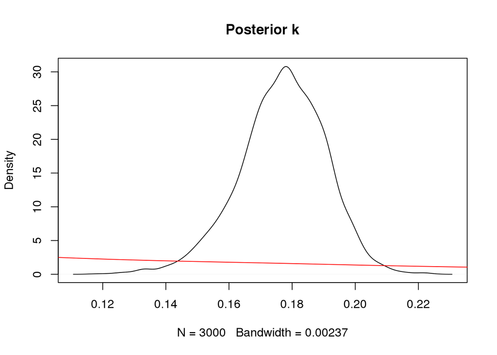

```r
#gamma.sims = out.gamma$BUGSoutput$sims.matrix
gamma.sims = as.mcmc(out.gamma)
gamma.chains = as.matrix(gamma.sims)

plot(density(gamma.chains[,"k"]), main = "Posterior k")
lines(density(k.sims), col = "red")
```

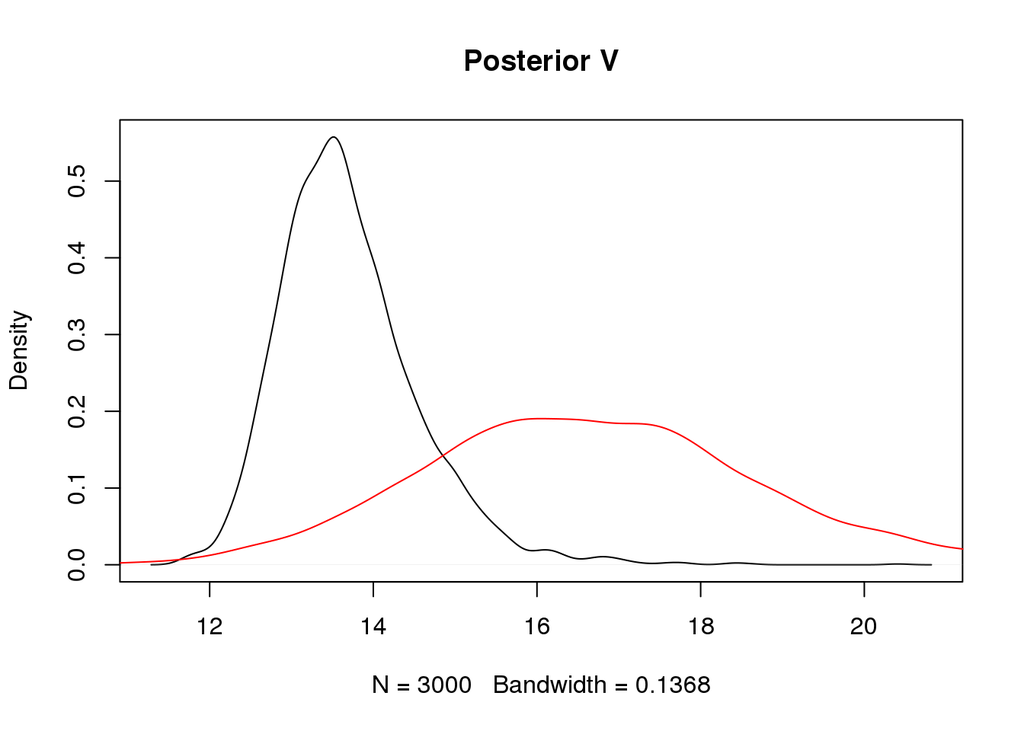

```r
plot(density(gamma.chains[,"v"]), main = "Posterior V")
lines(density(v.sims),col = "red")
```

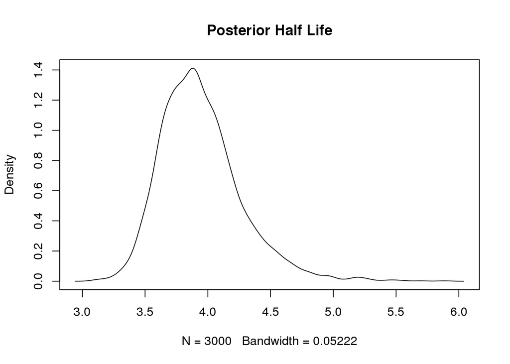

```r
plot(density(gamma.chains[,"halflife"]),main = "Posterior Half Life")
```

```r
apply(gamma.chains,2,quantile,c(.025,.975))
```

```
##        deviance halflife         k       phi      sigma        v       vk
## 2.5%  -26.77595 3.439952 0.1477408  63.97938 0.03293116 12.37314 2.206920
## 97.5% -13.99798 4.691643 0.2014991 922.11844 0.12502017 15.62866 2.611299
```

```r
conc.lm = lm(I(log(y) - log(30)) ~ x)

vhat = exp(-coef(conc.lm)[1])
khat = -coef(conc.lm)[2]


df = data.frame(y=y, x=x)
logconc.nlm = nls( log(y) ~ log((30/V)*exp(-k*x)), data=df, start=list(V=vhat, k=khat))
summary(logconc.nlm)
```

```
##
## Formula: log(y) ~ log((30/V) * exp(-k * x))
##
## Parameters:
##               Estimate Std. Error t value Pr(>|t|)
## V.(Intercept) 16.66331    7.11923   2.341 0.057796 .
## k.x            0.15211    0.02368   6.423 0.000673 ***
## ---
## Signif. codes:  0 '***' 0.001 '**' 0.01 '*' 0.05 '.' 0.1 ' ' 1
##
## Residual standard error: 0.7411 on 6 degrees of freedom
##
## Number of iterations to convergence: 0
## Achieved convergence tolerance: 4.056e-09
```

```r
conc.nlm = nls( y ~ (30/V)*exp(-k*x), data=df, start=list(V=vhat, k=khat))
summary(conc.nlm)
```

```
##
## Formula: y ~ (30/V) * exp(-k * x)
##
## Parameters:
##   Estimate Std. Error t value Pr(>|t|)
## V 13.06506    0.60899   21.45 6.69e-07 ***
## k  0.18572    0.01124   16.52 3.14e-06 ***
## ---
## Signif. codes:  0 '***' 0.001 '**' 0.01 '*' 0.05 '.' 0.1 ' ' 1
##
## Residual standard error: 0.05126 on 6 degrees of freedom
##
## Number of iterations to convergence: 4
## Achieved convergence tolerance: 7.699e-06
```

```r
confint(conc.nlm)
```

```
##         2.5%      97.5%
## V 11.6318218 14.7032581
## k  0.1584731  0.2155565
```

These are ery similar to the frequentist methods we discussed previously. We can also wee using these plots that our prior probaly wasn’t the best.